# Final Project

#### scree plot을 통해 요인수를 1로 결정

```r
Gangwon_fa <- fa(Gangwon, nfactors=1, n.obs=N, rotate="varimax")
print(Gangwon_fa$loadings, cutoff = 0.2)
```

```
##
## Loadings:
##         MR1
## company 0.903
## rate2   0.903
##
##                  MR1
## SS loadings    1.629
## Proportion Var 0.815
```

```r
colnames(Gangwon_fa$loadings) <- c("Factor1")
fa.diagram(Gangwon_fa)
```

[output not shown]

#### 강원도의 경우 다음과 같은 요인분석 결과를 얻는다.

- $ company = 0.903 * Factor1 $
- $ rate2 = 0.903 * Factor1 $
- Factor1은 강원도의 산업별 사업체수 및 종사자 비율과 관련한 잠재요인으로 보여진다.

### 충청북도

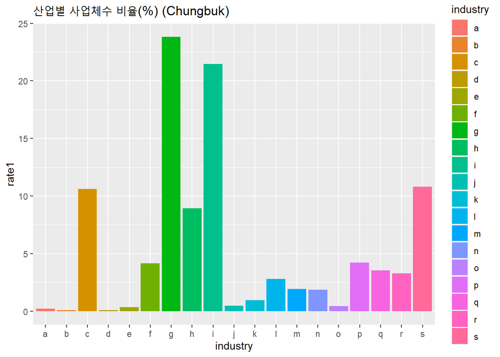

```r
Chungbuk <- final[final$spot=="Chungbuk",c(2,3,4,5,6)]
ggplot(Chungbuk, aes(x=industry, y=rate1, fill=industry)) +
   geom_bar(stat="identity") +
   ggtitle("산업별 사업체수 비율(%) (Chungbuk)")
```

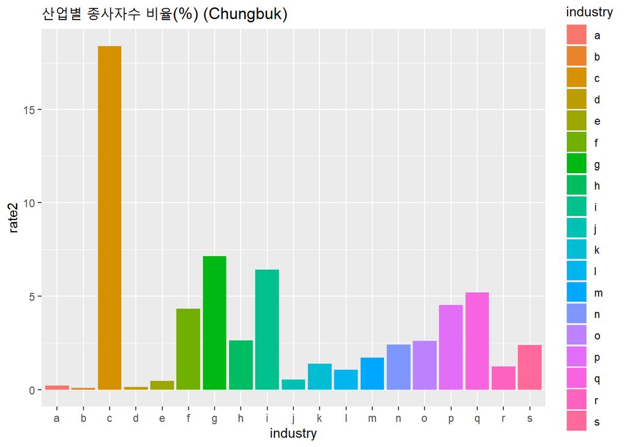

```r
ggplot(Chungbuk, aes(x=industry, y=rate2, fill=industry)) +
   geom_bar(stat="identity") +
   ggtitle("산업별 종사자수 비율(%) (Chungbuk)")
```

#### 충청북도의 경우 사업체수는 도매 및 소매업이 1위, 숙박 및 음식점업이 2위를 기록한 반면에, 종사자 비율은 제조업이 압도적으로 큼.

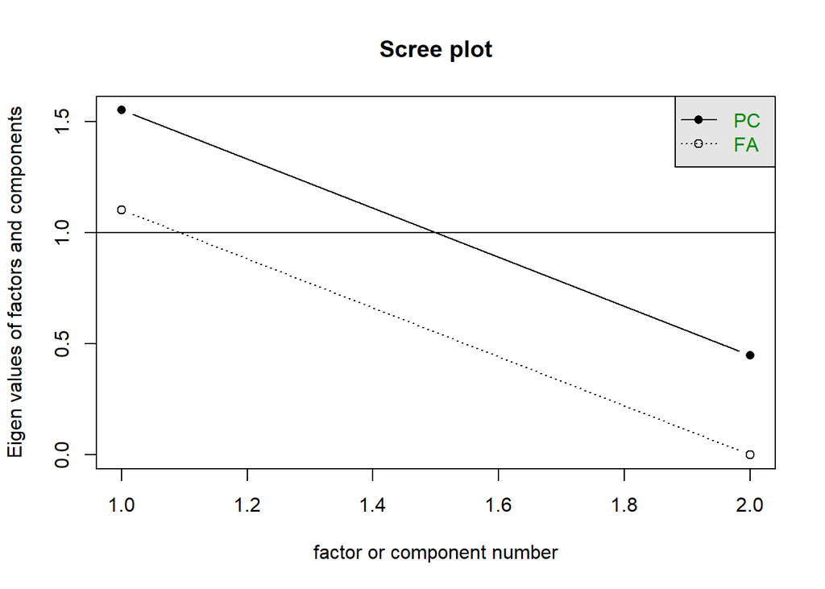

```r
# 요인수 결정
Chungbuk <- final[final$spot=="Chungbuk",c(3,6)]
Chungbuk_cor <- cor(Chungbuk, use = "pairwise.complete.obs")
scree(Chungbuk_cor, factors = TRUE)
```

#### scree plot을 통해 요인수를 1로 결정

```r
Chungbuk_fa <- fa(Chungbuk, nfactors=1, n.obs=N, rotate="varimax")
print(Chungbuk_fa$loadings, cutoff = 0.2)
```

```
##
## Loadings:
##         MR1
## company 0.743
## rate2   0.743
##
##                  MR1
## SS loadings    1.104
## Proportion Var 0.552
```

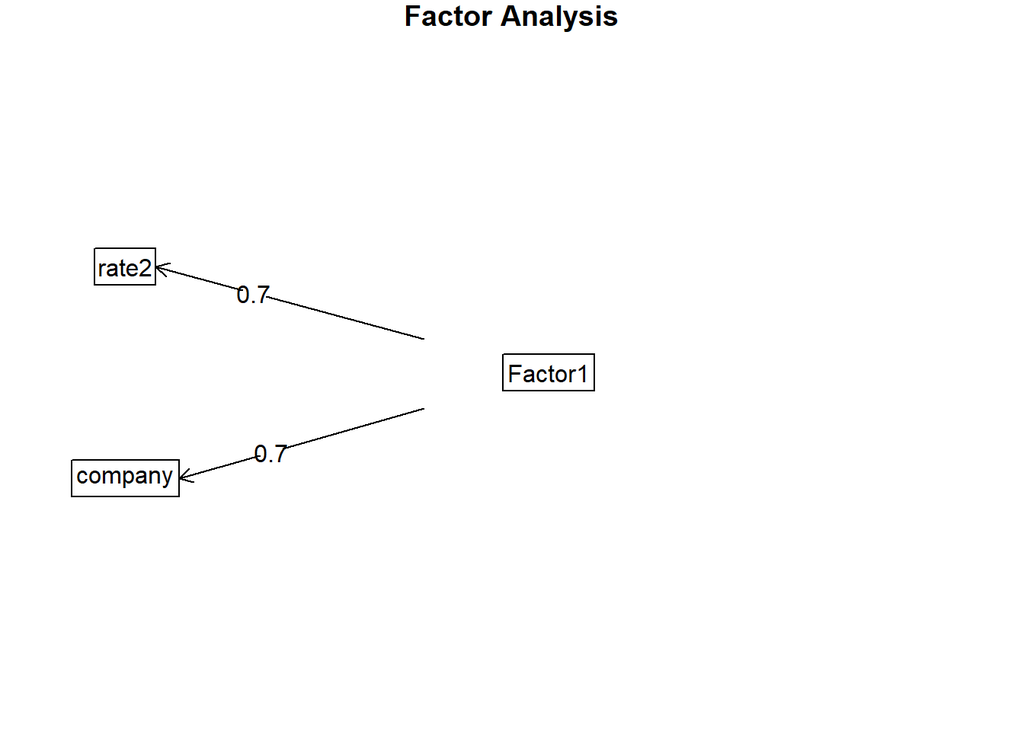

```r
colnames(Chungbuk_fa$loadings) <- c("Factor1")
fa.diagram(Chungbuk_fa)
```

#### 충청북도의 경우 다음과 같은 요인분석 결과를 얻는다.

- $ company = 0.743 * Factor1 $
- $ rate2 = 0.743 * Factor1 $
- Factor1은 충청북도의 산업별 사업체수 및 종사자 비율과 관련한 잠재요인으로 보여진다.

### 충청남도

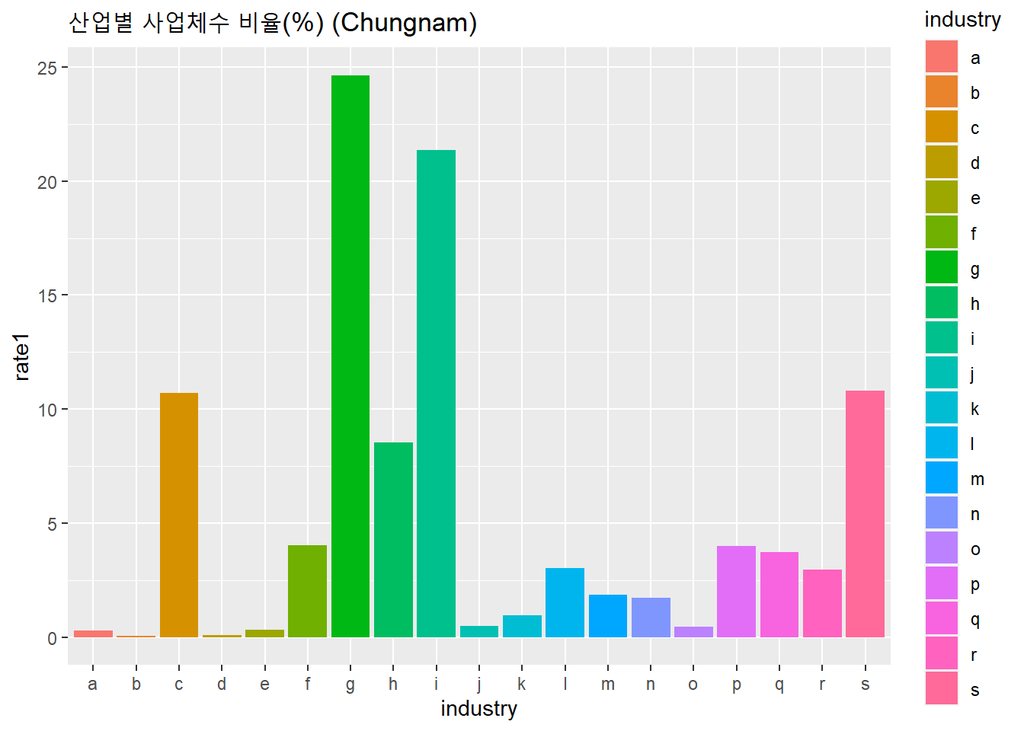

```r
Chungnam <- final[final$spot=="Chungnam",c(2,3,4,5,6)]
ggplot(Chungnam, aes(x=industry, y=rate1, fill=industry)) +
   geom_bar(stat="identity") +
   ggtitle("산업별 사업체수 비율(%) (Chungnam)")
```

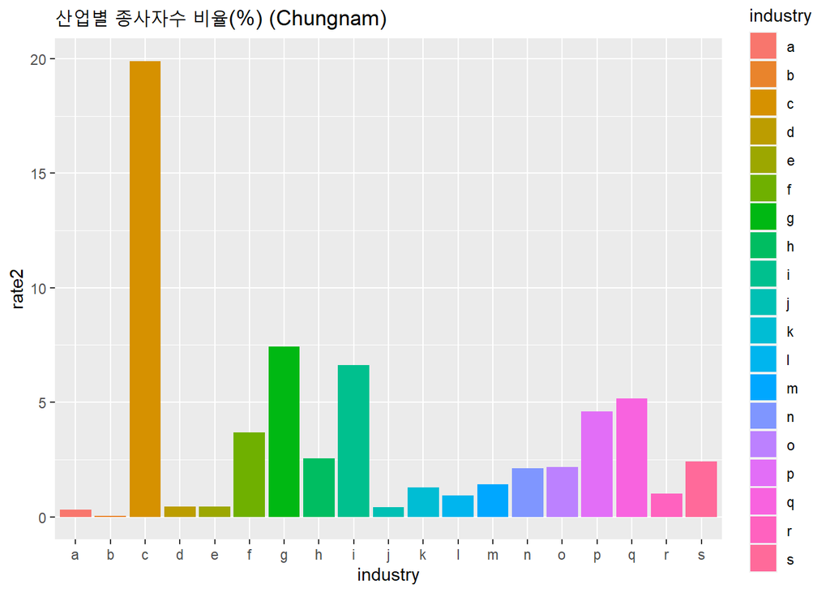

```r
ggplot(Chungnam, aes(x=industry, y=rate2, fill=industry)) +
   geom_bar(stat="identity") +
   ggtitle("산업별 종사자수 비율(%) (Chungnam)")
```

#### 충청남도의 경우 사업체수는 도매 및 소매업이 1위, 숙박 및 음식점업이 2위를 기록한 반면에, 종사자 비율은 제조업이 압도적으로 큼.

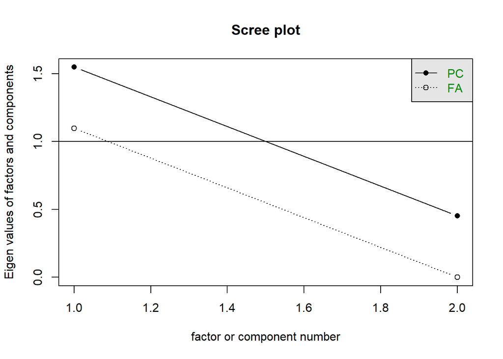

```r
# 요인수 결정
Chungnam <- final[final$spot=="Chungnam",c(3,6)]
Chungnam_cor <- cor(Chungnam, use = "pairwise.complete.obs")
scree(Chungnam_cor, factors = TRUE)
```

#### scree plot을 통해 요인수를 1로 결정

```r
Chungnam_fa <- fa(Chungnam, nfactors=1, n.obs=N, rotate="varimax")
print(Chungnam_fa$loadings, cutoff = 0.2)
```

```
##
## Loadings:
##         MR1
## company 0.74
## rate2   0.74
##
##                  MR1
## SS loadings    1.096
## Proportion Var 0.548
```

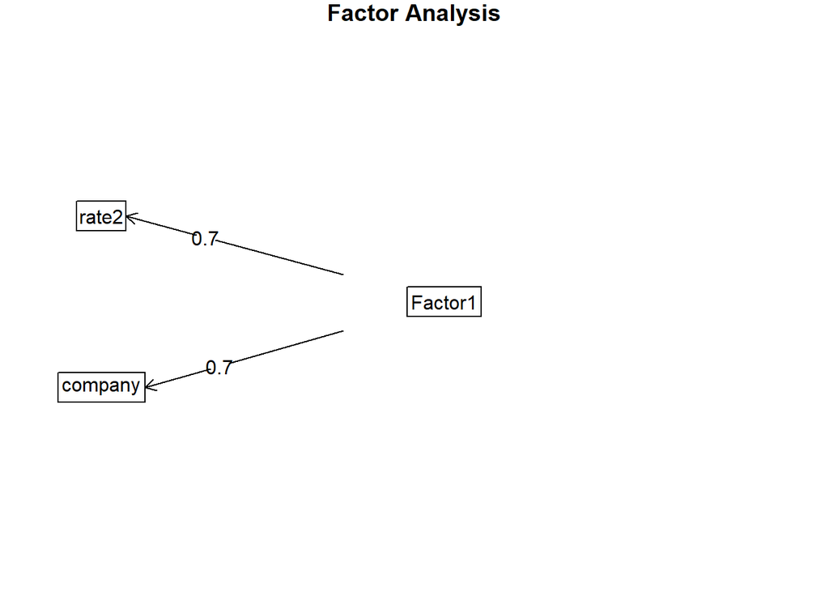

```r
colnames(Chungnam_fa$loadings) <- c("Factor1")
fa.diagram(Chungnam_fa)
```

#### 충청남도의 경우 다음과 같은 요인분석 결과를 얻는다.

- $ company = 0.740 * Factor1 $
- $ rate2 = 0.740 * Factor1 $
- Factor1은 충청남도의 산업별 사업체수 및 종사자 비율과 관련한 잠재요인으로 보여진다.

### 전라북도

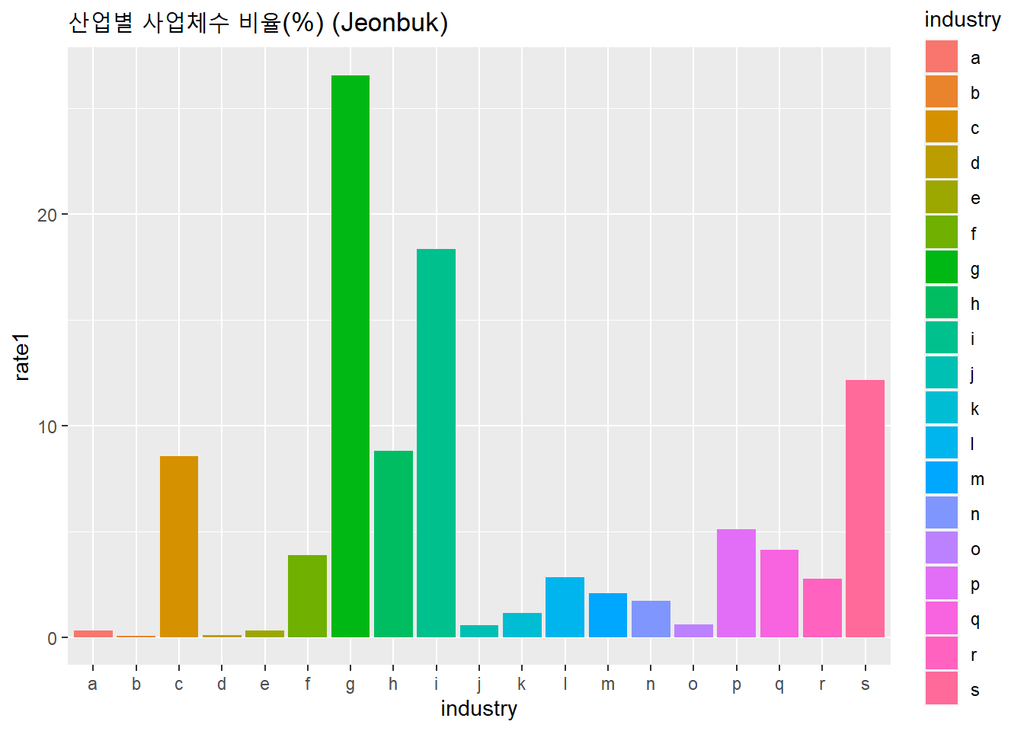

```r
Jeonbuk <- final[final$spot=="Jeonbuk",c(2,3,4,5,6)]
ggplot(Jeonbuk, aes(x=industry, y=rate1, fill=industry)) +
   geom_bar(stat="identity") +
   ggtitle("산업별 사업체수 비율(%) (Jeonbuk)")
```

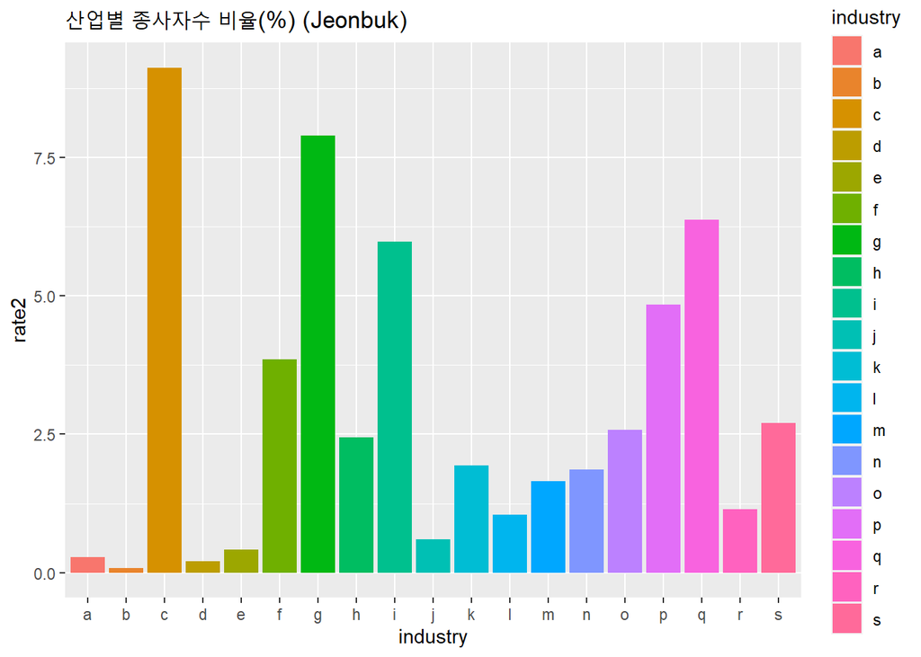

```r
ggplot(Jeonbuk, aes(x=industry, y=rate2, fill=industry)) +
   geom_bar(stat="identity") +
   ggtitle("산업별 종사자수 비율(%) (Jeonbuk)")
```

#### 전라북도의 경우 사업체수는 도매 및 소매업이 1위, 숙박 및 음식점업이 2위를 기록한 반면에, 종사자 비율은 제조업이 1위, 도매 및 소매업이 2위를 기록함.

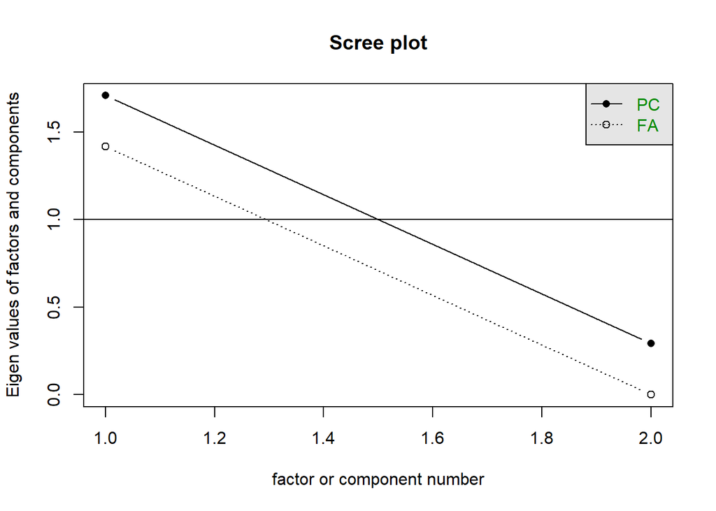

```r
# 요인수 결정
Jeonbuk <- final[final$spot=="Jeonbuk",c(3,6)]
Jeonbuk_cor <- cor(Jeonbuk, use = "pairwise.complete.obs")
scree(Jeonbuk_cor, factors = TRUE)
```

#### scree plot을 통해 요인수를 1로 결정

```r
Jeonbuk_fa <- fa(Jeonbuk, nfactors=1, n.obs=N, rotate="varimax")
print(Jeonbuk_fa$loadings, cutoff = 0.2)
```

```
##
## Loadings:
##         MR1
## company 0.841
## rate2   0.841
##
##                  MR1
## SS loadings    1.416
## Proportion Var 0.708
```

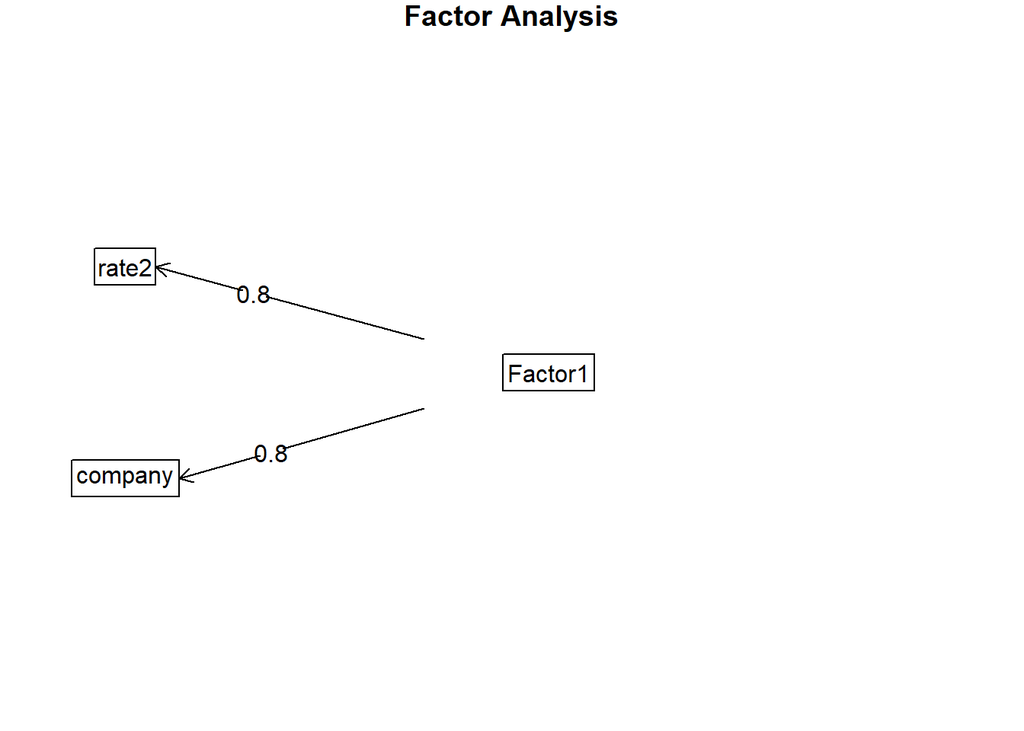

```r
colnames(Jeonbuk_fa$loadings) <- c("Factor1")
fa.diagram(Jeonbuk_fa)
```

#### 전라북도의 경우 다음과 같은 요인분석 결과를 얻는다.

- $ company = 0.841 * Factor1 $
- $ rate2 = 0.841 * Factor1 $
- Factor1은 전라북도의 산업별 사업체수 및 종사자 비율과 관련한 잠재요인으로 보여진다.

### 전라남도

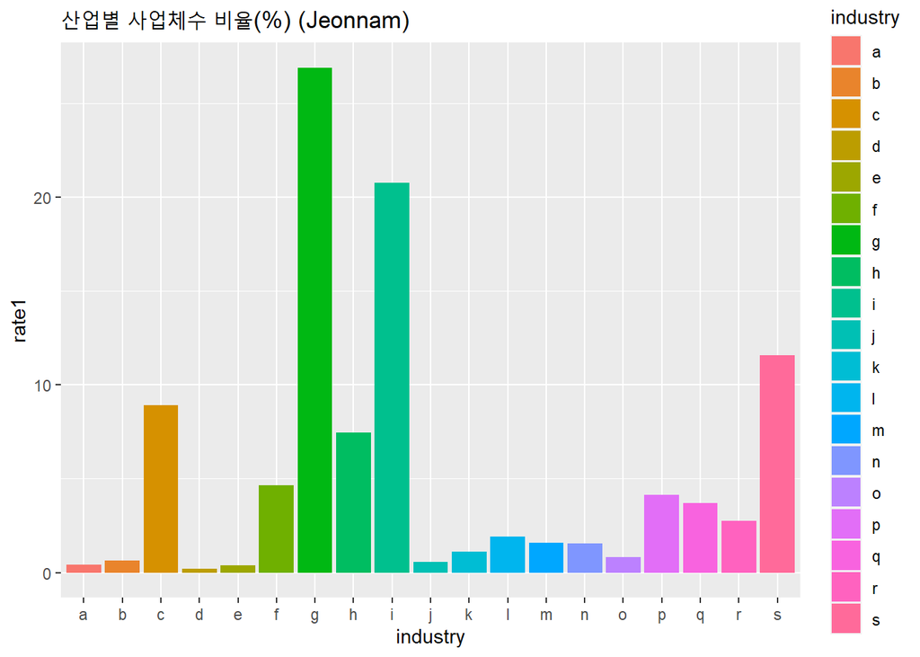

```r
Jeonnam <- final[final$spot=="Jeonnam",c(2,3,4,5,6)]
ggplot(Jeonnam, aes(x=industry, y=rate1, fill=industry)) +
   geom_bar(stat="identity") +
   ggtitle("산업별 사업체수 비율(%) (Jeonnam)")
```

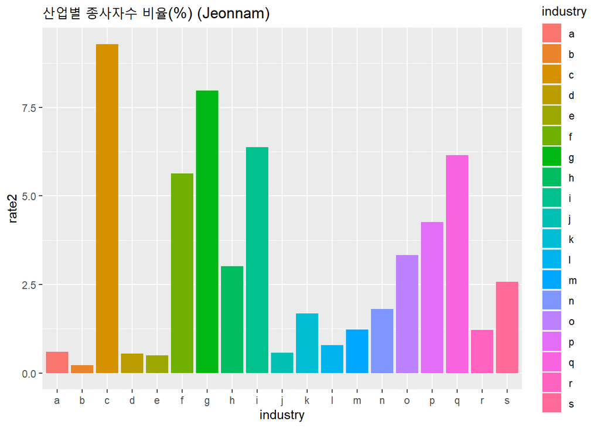

```r
ggplot(Jeonnam, aes(x=industry, y=rate2, fill=industry)) +
   geom_bar(stat="identity") +
   ggtitle("산업별 종사자수 비율(%) (Jeonnam)")
```

#### 전라남도의 경우 사업체수는 도매 및 소매업이 1위, 숙박 및 음식점업이 2위를 기록한 반면에, 종사자 비율은 제조업이 1위, 도매 및 소매업이 2위를 기록함.

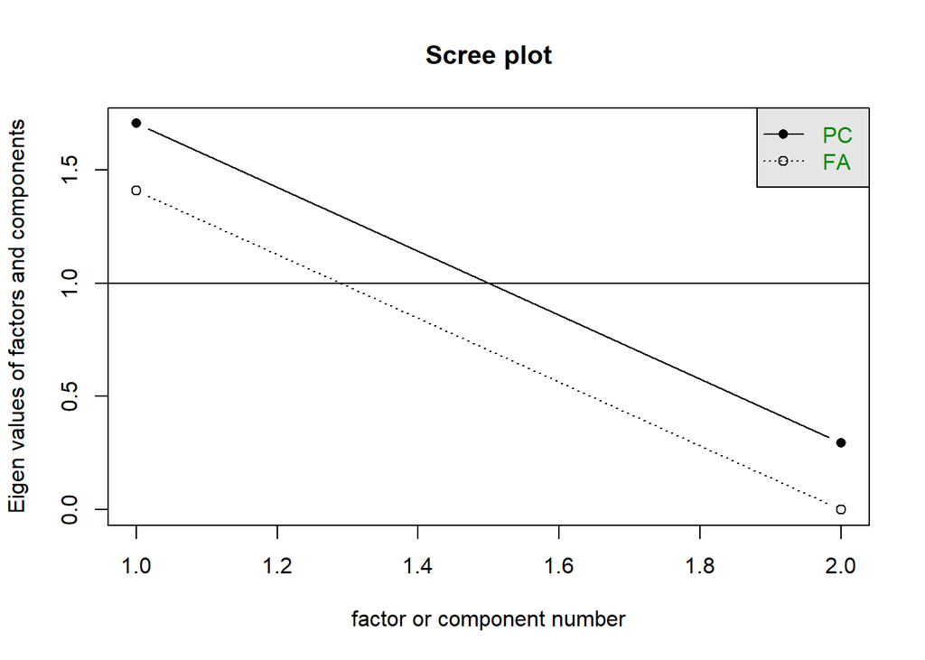

```r
# 요인수 결정
Jeonnam <- final[final$spot=="Jeonnam",c(3,6)]
Jeonnam_cor <- cor(Jeonnam, use = "pairwise.complete.obs")
scree(Jeonnam_cor, factors = TRUE)
```

#### scree plot을 통해 요인수를 1로 결정

```r
Jeonnam_fa <- fa(Jeonnam, nfactors=1, n.obs=N, rotate="varimax")
print(Jeonnam_fa$loadings, cutoff = 0.2)
```

```
##
## Loadings:
##         MR1
## company 0.839
## rate2   0.839
##
##                  MR1
## SS loadings    1.409
## Proportion Var 0.704
```

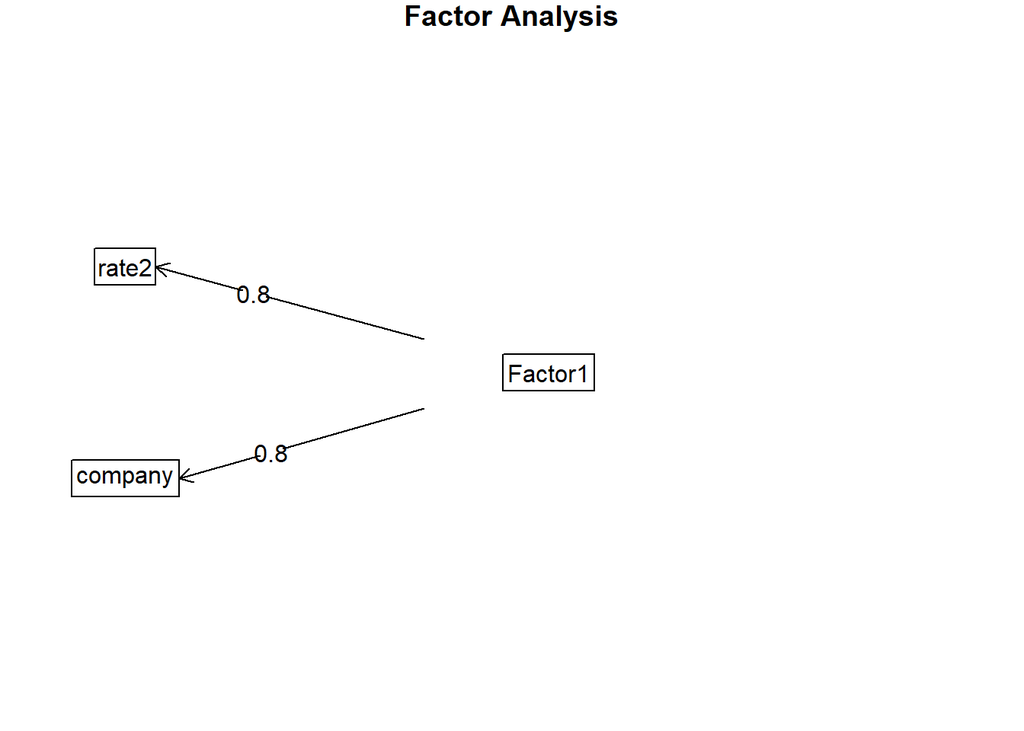

```r
colnames(Jeonnam_fa$loadings) <- c("Factor1")
fa.diagram(Jeonnam_fa)
```

#### 전라남도의 경우 다음과 같은 요인분석 결과를 얻는다.

- $ company = 0.839 * Factor1 $
- $ rate2 = 0.839 * Factor1 $
- Factor1은 전라남도의 산업별 사업체수 및 종사자 비율과 관련한 잠재요인으로 보여진다.

### 경상북도

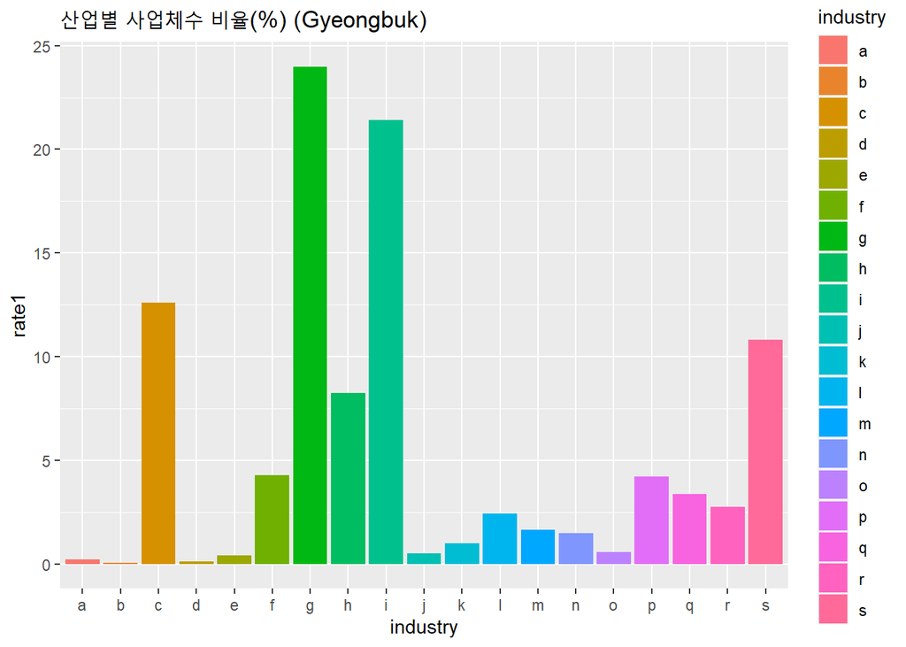

```r
Gyeongbuk <- final[final$spot=="Gyeongbuk",c(2,3,4,5,6)]
ggplot(Gyeongbuk, aes(x=industry, y=rate1, fill=industry)) +
   geom_bar(stat="identity") +
   ggtitle("산업별 사업체수 비율(%) (Gyeongbuk)")
```

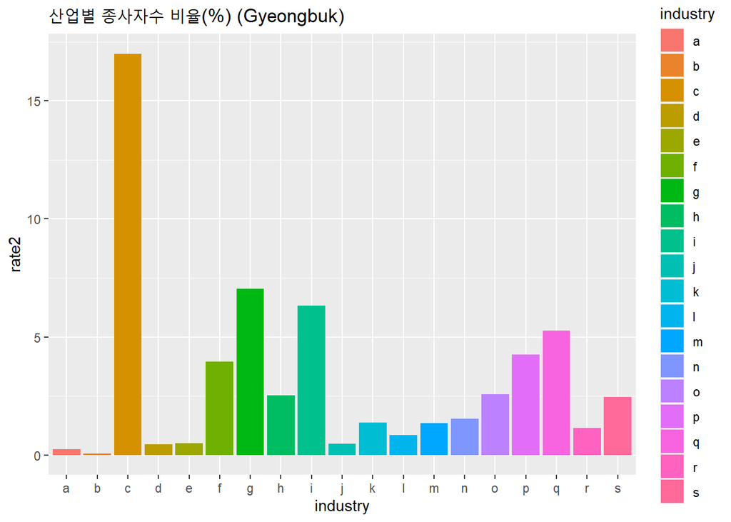

```r
ggplot(Gyeongbuk, aes(x=industry, y=rate2, fill=industry)) +
   geom_bar(stat="identity") +
   ggtitle("산업별 종사자수 비율(%) (Gyeongbuk)")
```

#### 경상북도의 경우 사업체수는 도매 및 소매업이 1위, 숙박 및 음식점업이 2위를 기록한 반면에, 종사자 비율은 제조업이 압도적으로 큼.

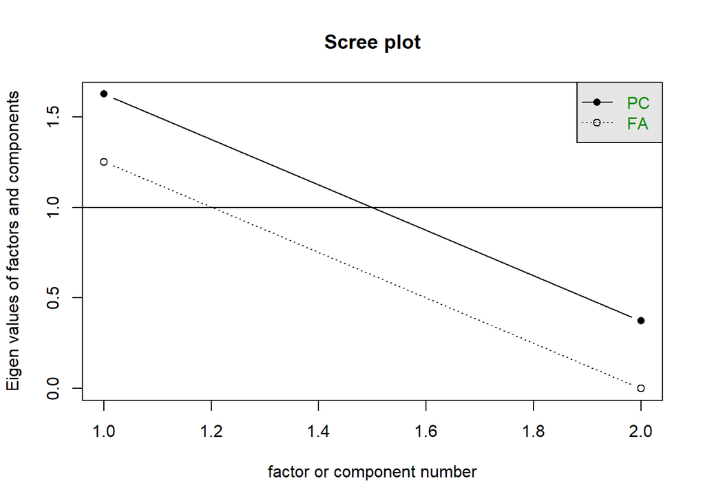

```r
# 요인수 결정
Gyeongbuk <- final[final$spot=="Gyeongbuk",c(3,6)]
Gyeongbuk_cor <- cor(Gyeongbuk, use = "pairwise.complete.obs")
scree(Gyeongbuk_cor, factors = TRUE)
```

#### scree plot을 통해 요인수를 1로 결정

```r
Gyeongbuk_fa <- fa(Gyeongbuk, nfactors=1, n.obs=N, rotate="varimax")
print(Gyeongbuk_fa$loadings, cutoff = 0.2)
```

```
##
## Loadings:
##         MR1
## company 0.791
## rate2   0.791
##
##                  MR1
## SS loadings    1.252
## Proportion Var 0.626
```

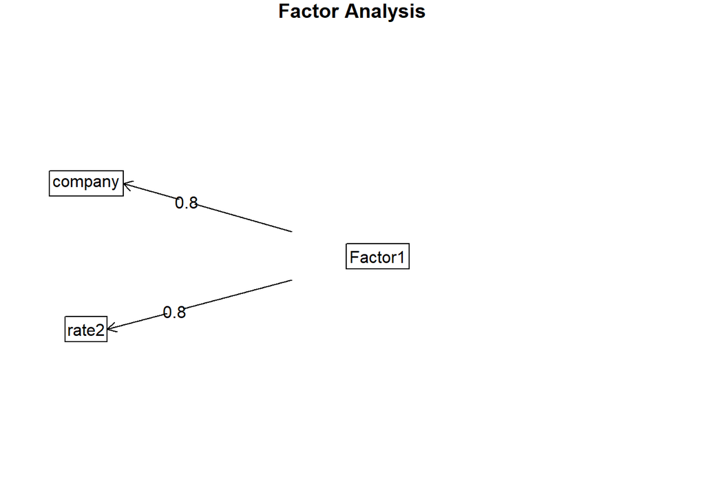

```r
colnames(Gyeongbuk_fa$loadings) <- c("Factor1")
fa.diagram(Gyeongbuk_fa)
```

#### 경상북도의 경우 다음과 같은 요인분석 결과를 얻는다.

- $ company = 0.791 * Factor1 $
- $ rate2 = 0.791 * Factor1 $
- Factor1은 경상북도의 산업별 사업체수 및 종사자 비율과 관련한 잠재요인으로 보여진다.

### 경상남도

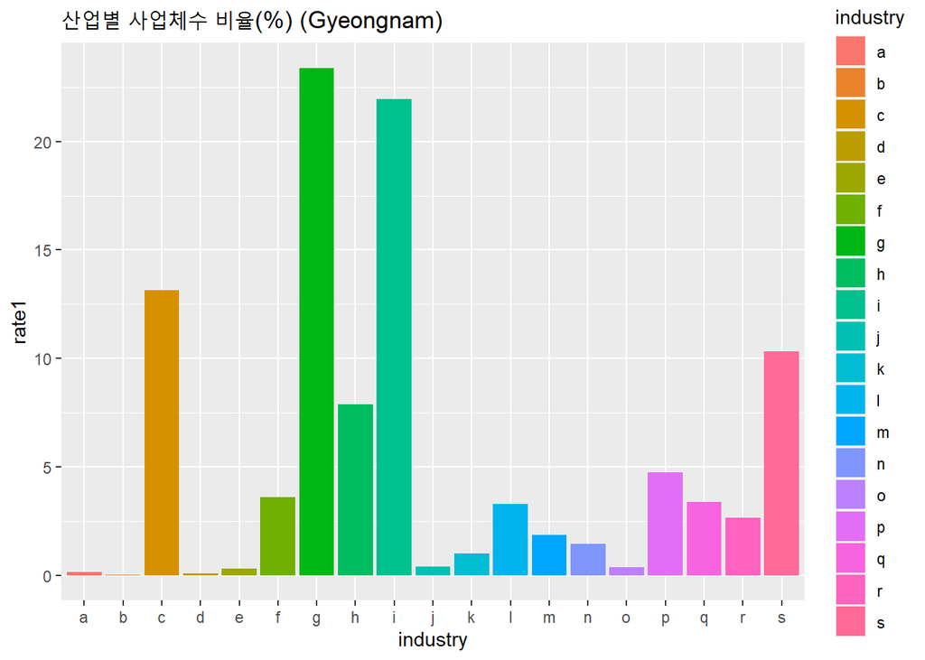

```r
Gyeongnam <- final[final$spot=="Gyeongnam",c(2,3,4,5,6)]
ggplot(Gyeongnam, aes(x=industry, y=rate1, fill=industry)) +
   geom_bar(stat="identity") +
   ggtitle("산업별 사업체수 비율(%) (Gyeongnam)")
```

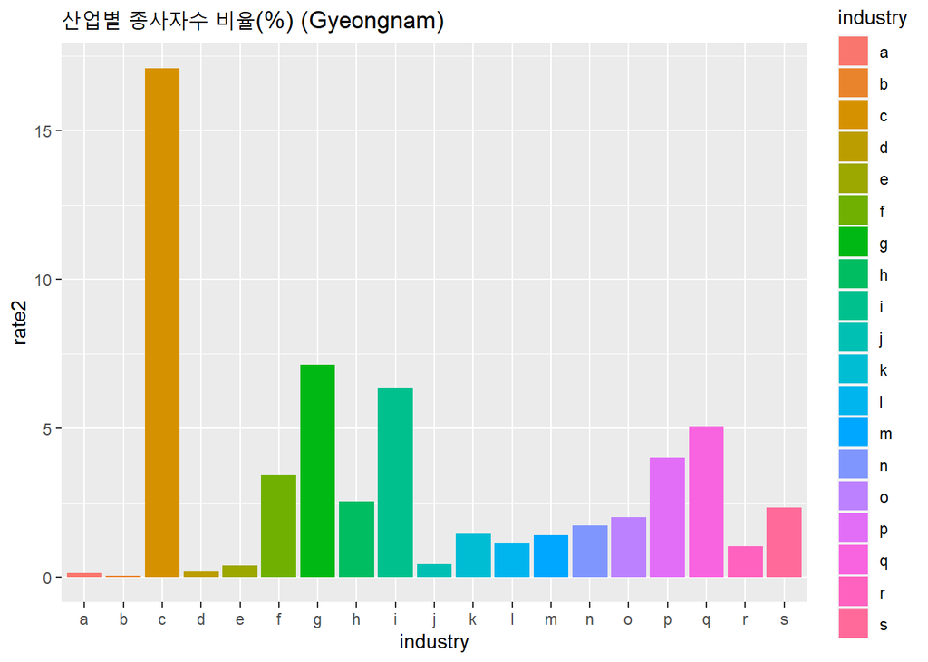

```r
ggplot(Gyeongnam, aes(x=industry, y=rate2, fill=industry)) +
   geom_bar(stat="identity") +
   ggtitle("산업별 종사자수 비율(%) (Gyeongnam)")
```

#### 경상남도의 경우 사업체수는 도매 및 소매업이 1위, 숙박 및 음식점업이 2위를 기록한 반면에, 종사자 비율은 제조업이 압도적으로 큼.

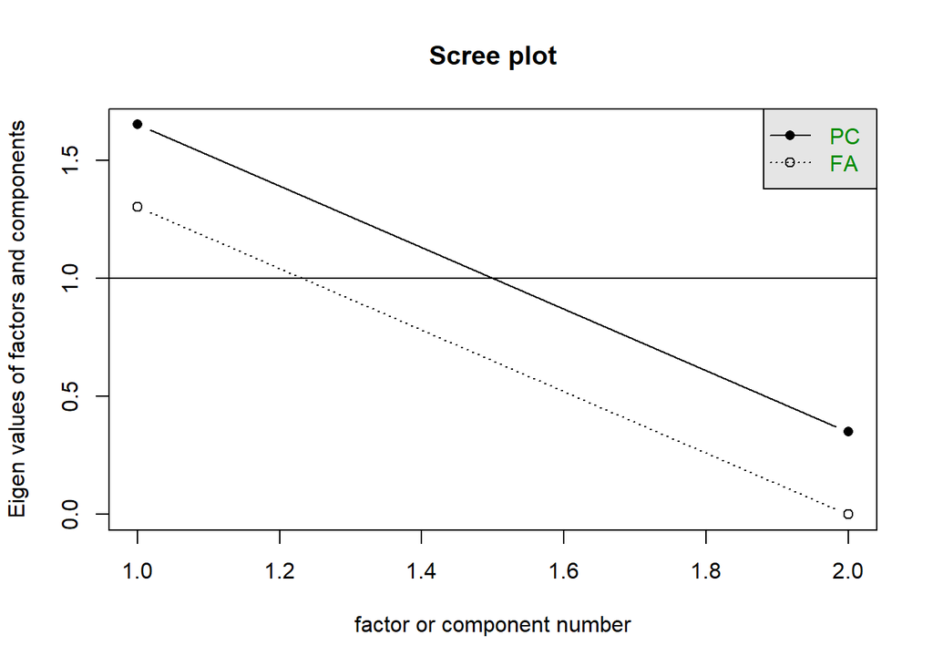

```r
# 요인수 결정
Gyeongnam <- final[final$spot=="Gyeongnam",c(3,6)]
Gyeongnam_cor <- cor(Gyeongnam, use = "pairwise.complete.obs")
scree(Gyeongnam_cor, factors = TRUE)
```

#### scree plot을 통해 요인수를 1로 결정

```r
Gyeongnam_fa <- fa(Gyeongnam, nfactors=1, n.obs=N, rotate="varimax")
print(Gyeongnam_fa$loadings, cutoff = 0.2)
```

```
##
## Loadings:
##         MR1
## company 0.806
## rate2   0.806
##
##                  MR1
## SS loadings    1.301
## Proportion Var 0.650
```

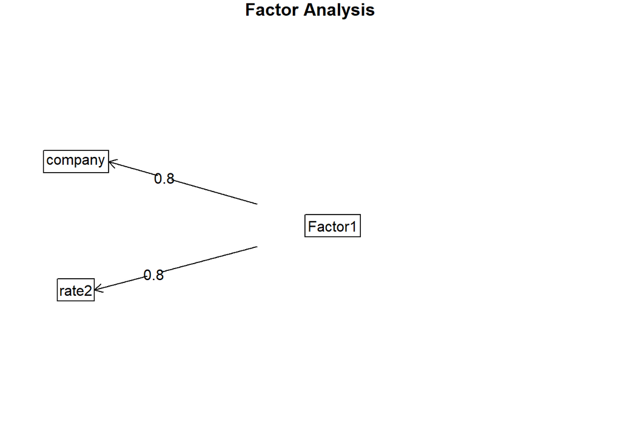

```r
colnames(Gyeongnam_fa$loadings) <- c("Factor1")
fa.diagram(Gyeongnam_fa)
```

#### 경상남도의 경우 다음과 같은 요인분석 결과를 얻는다.

- $ company = 0.807 * Factor1 $
- $ rate = 0.807 * Factor1 $
- Factor1은 경상남도의 산업별 사업체수 및 종사자 비율과 관련한 잠재요인으로 보여진다.

### 제주도

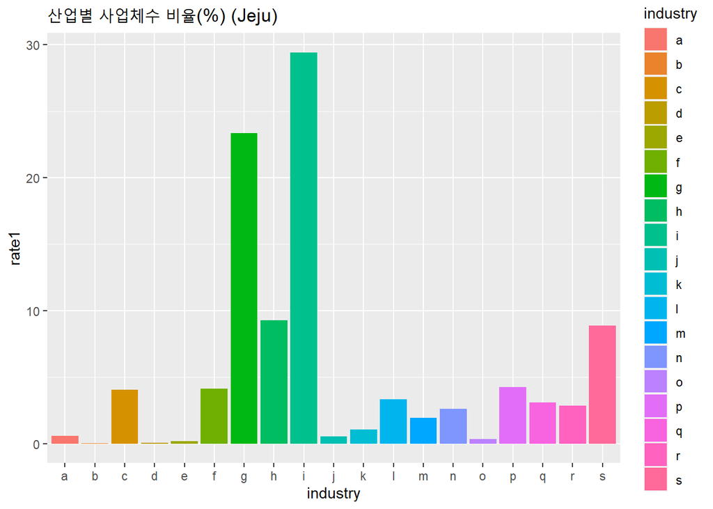

```r
Jeju <- final[final$spot=="Jeju",c(2,3,4,5,6)]
ggplot(Jeju, aes(x=industry, y=rate1, fill=industry)) +
   geom_bar(stat="identity") +
   ggtitle("산업별 사업체수 비율(%) (Jeju)")
```

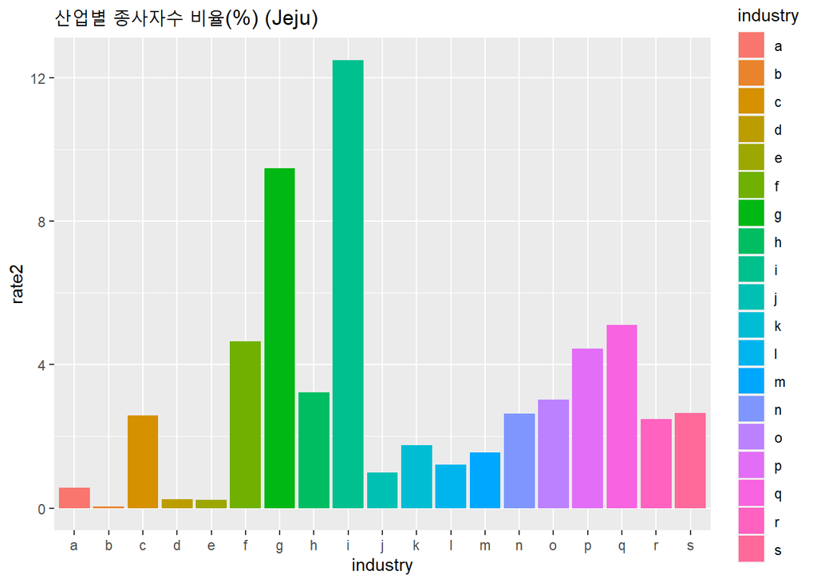

```r
ggplot(Jeju, aes(x=industry, y=rate2, fill=industry)) +
   geom_bar(stat="identity") +
   ggtitle("산업별 종사자수 비율(%) (Jeju)")
```

#### 제주도의 경우 숙박 및 음식점업이 1위, 도매 및 소매업이 2위를 기록함.

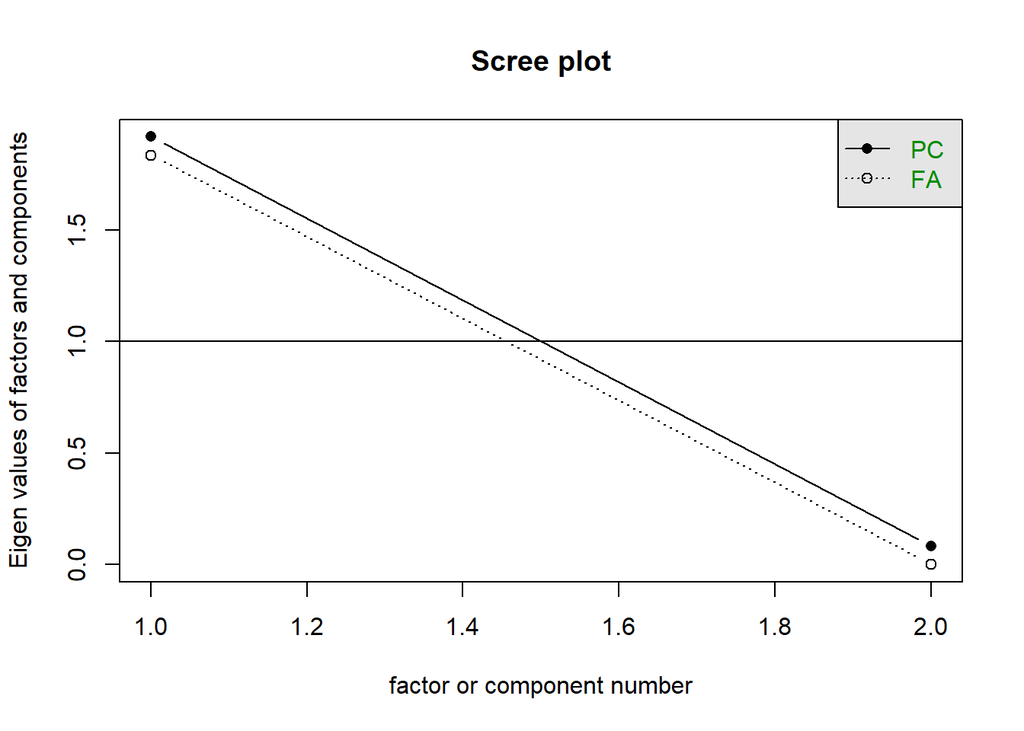

```r
# 요인수 결정
Jeju <- final[final$spot=="Jeju",c(3,6)]
Jeju_cor <- cor(Jeju, use = "pairwise.complete.obs")
scree(Jeju_cor, factors = TRUE)
```

#### scree plot을 통해 요인수를 1로 결정

```r
Jeju_fa <- fa(Jeju, nfactors=1, n.obs=N, rotate="varimax")
print(Jeju_fa$loadings, cutoff = 0.2)
```

```
##
## Loadings:
##         MR1
## company 0.958
## rate2   0.958
##
##                  MR1
## SS loadings    1.835
## Proportion Var 0.918
```

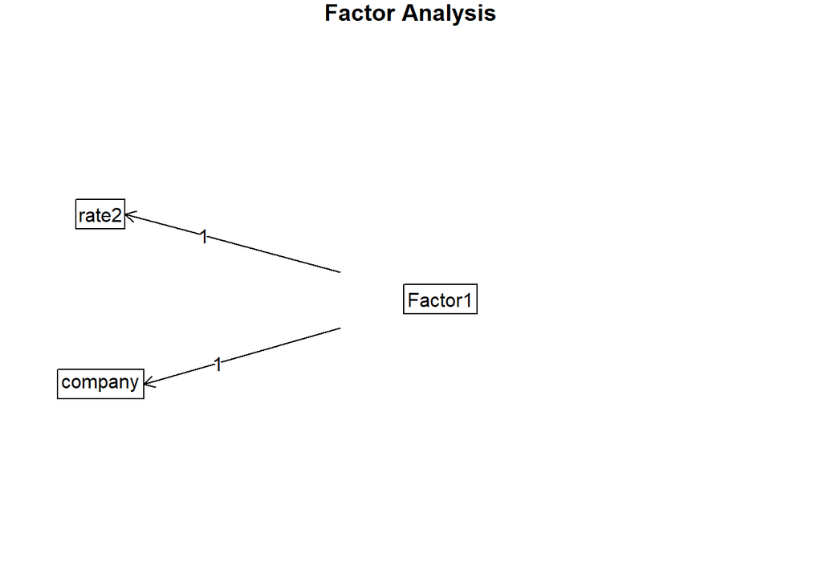

```r
colnames(Jeju_fa$loadings) <- c("Factor1")
fa.diagram(Jeju_fa)
```

#### 제주도의 경우 다음과 같은 요인분석 결과를 얻는다.

- $ company = 0.958 * Factor1 $
- $ rate2 = 0.958 * Factor1 $
- Factor1은 제주도의 산업별 사업체수 및 종사자 비율과 관련한 잠재요인으로 보여진다.

### (5) 요인분석 결과를 총평하시오.

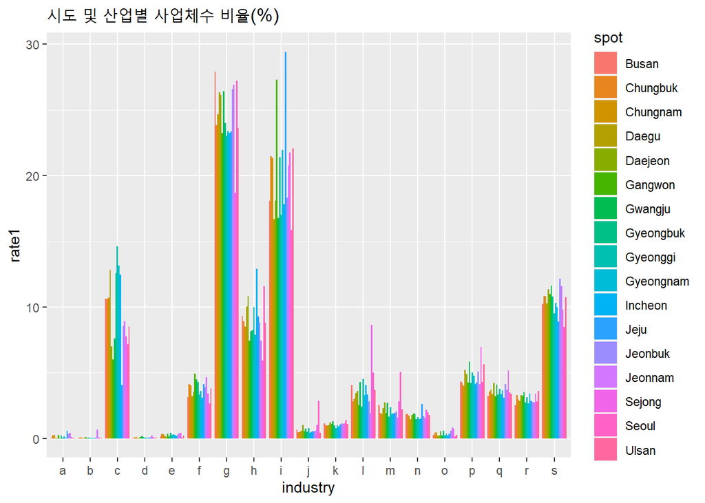

```r
ggplot(final, aes(x=industry, y=rate1, fill=spot)) +
   geom_bar(stat="identity",position="dodge") +
   ggtitle("시도 및 산업별 사업체수 비율(%)")
```

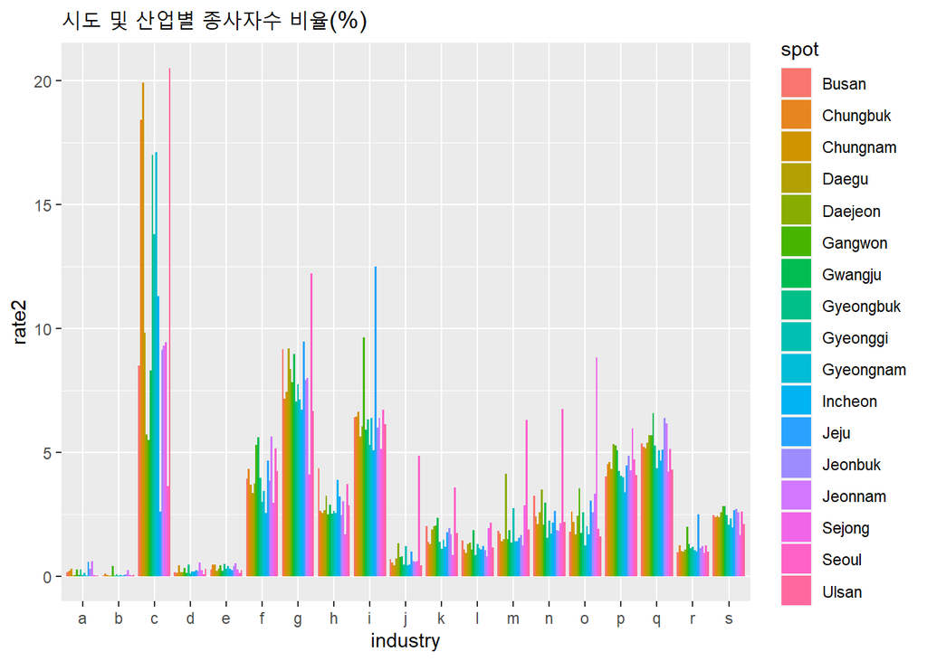

```r
ggplot(final, aes(x=industry, y=rate2, fill=spot)) +
   geom_bar(stat="identity",position="dodge") +
   ggtitle("시도 및 산업별 종사자수 비율(%)")
```

- 다른 시도와는 다르게 세종시의 경우 정부세종청사가 있기 때문에 공공행정, 국방 및 사회보장 행정 직군 종사자수가 많게 나왔고, 제주도의 경우 관광산업이 주로 이루어지는 만큼 숙박 및 음식점업에 해당하는 사업체수나 종사자수가 가장 많았다. 이를 통해 세종시와 제주도가 다른 시도와는 다른 특별한 특성을 나타내고 있다고 판단된다.